# HW 10 - Tim Demetriades

11/14/2021

### Part II

#### Use data1.csv file for auto-encoder test.

#### 1. Use only the first 28 columns V1-V28 to test vanilla auto-encoder with 1-layer for encoder and decoder (hidden layer nodes = 2). Plot the histogram plot of reconstruction errors.

```python
from keras.layers import Input, Dense
from keras.models import Model
from keras.datasets import mnist
from sklearn.model_selection import train_test_split
from sklearn.preprocessing import MinMaxScaler

import matplotlib.pyplot as plt
import numpy as np
```

```python
# this is the size of our encoded representations
encoding_dim = 2
```

```python
# this is our input placeholder
input_img = Input(shape=(28,))
# "encoded" is the encoded representation of the input
encoded = Dense(encoding_dim, activation='relu')(input_img)
# "decoded" is the lossy reconstruction of the input
decoded = Dense(28, activation='sigmoid')(encoded)
```

```python
# this model maps an input to its reconstruction
autoencoder = Model(input_img, decoded)
# this model maps an input to its encoded representation
encoder = Model(input_img, encoded)
```

```python
# create a placeholder for an encoded (4-dimensional) input
encoded_input = Input(shape=(encoding_dim,))
# retrieve the last layer of the autoencoder model
decoder_layer = autoencoder.layers[-1]
# create the decoder model
decoder = Model(encoded_input, decoder_layer(encoded_input))
```

```python
# here the model is configured for training with an optimizer and loss function
autoencoder.compile(optimizer='adam', loss='binary_crossentropy')
```

```python
cols = []
for i in range(28):
    cols.append(i)
```

```python
# Load data from a text file
file_data = np.genfromtxt('data1.csv', delimiter=',', skip_header=1, skip_footer=3, usecols=cols)
```

```python
file_data.shape
```

```
(284807, 28)
```

```python
scaled_data = MinMaxScaler().fit_transform(file_data)
```

```python
x_train, x_test = train_test_split(scaled_data, test_size=0.3)
```

```python
print(x_train.shape)
print(x_test.shape)
```

```
(199364, 28)
(85443, 28)
```

```python
# the model is trained with the training data as both the input data and target data
autoencoder.fit(x_train, x_train,
                batch_size=256,
                epochs=10,
                validation_data=(x_test, x_test))
```

```
<keras.callbacks.History at 0x2e0ac543520>
```

```python
predictions = autoencoder.predict(x_train)
```

```python
differences = np.absolute(np.subtract(x_train, predictions))
differences = differences.sum(axis=1)
differences.shape
```

```
(199364,)
```

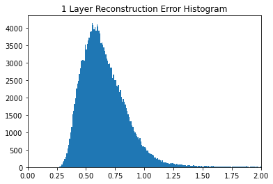

```python
plt.hist(differences, bins='auto')
plt.xlim((0.0, 2.0))
plt.title('1 Layer Reconstruction Error Histogram')
plt.show()
```

#### 2. Use only the first 28 columns V1-V28 to test Deep auto-encoder with at least 2-layers for encoder and decoder (final hidden layer nodes = 2). Plot the histogram plot of reconstruction errors. Compare this with step 1 results.

```python
# this is the size of our encoded representations
encoding_dim = 2
```

```python
# this is our input placeholder
input_img = Input(shape=(28,))
# "encoded" is the encoded representation of the input
encoded = Dense(14, activation='relu')(input_img)
encoded = Dense(encoding_dim, activation='relu')(encoded)
# "decoded" is the lossy reconstruction of the input
decoded = Dense(14, activation='sigmoid')(encoded)
decoded = Dense(28, activation='sigmoid')(decoded)
```

```python
# this model maps an input to its reconstruction
deep_autoencoder = Model(input_img, decoded)
# this model maps an input to its encoded representation
deep_encoder = Model(input_img, encoded)
```

```python
# create a placeholder for an encoded (4-dimensional) input
encoded_input = Input(shape=(encoding_dim,))
# retrieve the last layer of the autoencoder model
decoder_layer1 = deep_autoencoder.layers[-2]
decoder_layer2 = deep_autoencoder.layers[-1]
# create the decoder model
deep_decoder = Model(encoded_input, decoder_layer2(decoder_layer1(encoded_input)))
```

```python
# here the model is configured for training with an optimizer and loss function
deep_autoencoder.compile(optimizer='adam', loss='binary_crossentropy')
```

```python
# the model is trained with the training data as both the input data and target data
deep_autoencoder.fit(x_train, x_train,
                    epochs=10,
                    validation_data=(x_test, x_test))
```

```
<keras.callbacks.History at 0x2e0b5ccf970>
```

```python
deep_predictions = deep_autoencoder.predict(x_train)
```

```python
deep_differences = np.absolute(np.subtract(x_train, deep_predictions))
deep_differences = deep_differences.sum(axis=1)
deep_differences.shape
```

```
(199364,)
```

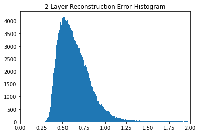

```python
plt.hist(deep_differences, bins='auto')
plt.xlim((0.0, 2.0))
plt.title('2 Layer Reconstruction Error Histogram')
plt.show()
```

As can be seen, the results for the 2 layer autoencoder are pretty similar to the results for the 1 layer autoencoder. Adding the second layer did **decrease the loss**, but not by a dastric amount.

#### 3. For both step 1 & 2, use hidden layer nodes = 2. Plot the scatter plots of the hidden layer vector samples.

#### 4. Use the column 29 "class" to put colors of the scatter plots in Step3. "0"-class with green and "1" class with red.

Doing both 3 and 4 at the same time instead of making two sets of scatter plots.

```python
label_data = np.genfromtxt('data1.csv', delimiter=',', skip_header=1, skip_footer=3, usecols=28)
```

```python
y_train, y_test = train_test_split(label_data, test_size=0.3)
```

```python
print(y_train.shape)
print(y_test.shape)
```

```
(199364,)
(85443,)
```

```python
hidden = encoder.predict(x_train)
hidden.shape
```

```
(199364, 2)
```

```python
deep_hidden = deep_encoder.predict(x_train)
deep_hidden.shape
```

```
(199364, 2)
```

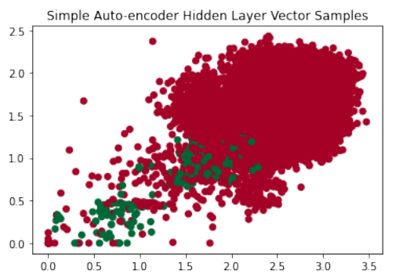

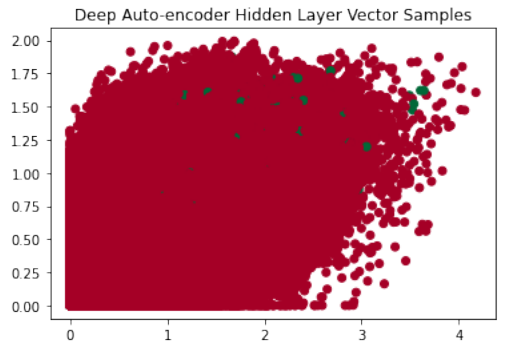

Here, we loaded in data from the csv file that was provided. The file had columns (dimensions) of data with the last column being the label, either 0 or 1. We trained a simple autoencoder with the data and then calculated the reconstruction error. A histogram was then created using that data. This process was repeated but with a deeper autoencoder by adding an extra layer of encoding and decoding. A new histogram was produced, which looks similar to the original but has slightly less loss, which makes sense as this histogram was made from the deeper model.

Finally, scatter plots were made using the encoded predictions from both models, which can be seen above. The red dots are class 0 and the green dots are class 1. It looks like both models tried to separate the two classes, seen best in the simple model (1st scatter plot), but both did have a hard time in general splitting up the two classes.

(Note - I was having problems creating these scatter plots in this notebook so I created these plots in a separate notebook and pasted them here.)